# Hearing general

# 1 Description of DataSchema variable

The description of harmonised variable is the following:

- Short name: `hearing_gen`
- Variable label: `Difficulty for hearing`
- Variable description: `It measures if the participant experiences some difficulty for hearing (i.e., hearing someone talking on the other side of the room in a normal voice) or not, using a hearing aid as usual`
- Domain: `Health status and functional limitations`
- Value type: `categorical`
- Category coding:

| **Code** | **Category Label** |
| --- | --- |
| 0 | Yes |
| 1 | No |

- Category missings:

| **Code** | **Category Label** |
| --- | --- |
| 991 | CAPI/interviewer error |
| 992 | Impute |
| 993 | Disable to measure |
| 994 | Not attempt/not done |
| 995 | Does not answer |
| 996 | Not applicable |
| 997 | Refuse |
| 998 | Do not know |
| 999 | Missing |

# 2 Data process

## 2.1 England

### 2.1.1 Wave 1

#### 2.1.1.1 Study-specific variable description

| **Name** | `hehear` |
| --- | --- |
| **Label** | `How is your hearing (using a hearing aid as usual)?` |
| **Table name** | `wave_1_core_data_v3` |
| **Categories** | `1 = ...excellent; 2 = very good; 3 = good; 4 = fair; 5 = or, poor?` |
| **Missings** | `-9 = Refusal; -8 = Don't Know` |
| **Description** |  |

hehear

| Sample size | Missing values |
| --- | --- |
| 12099 | 11 |

Category

|  | 1 | 2 | 3 | 4 | 5 |
| --- | --- | --- | --- | --- | --- |
| Frequency | 2826.00 | 3162.00 | 3549.00 | 1933.00 | 618.00 |
| Percentage | 23.36 | 26.13 | 29.33 | 15.98 | 5.11 |

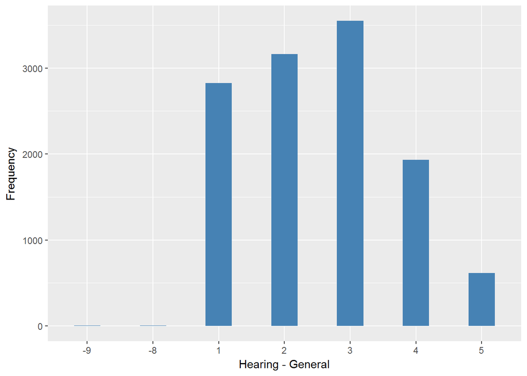

#### 2.1.1.2 Harmonisation algorithm

To compute the harmonize variable from the study-specific variable it has to be recoded as follows:

- `4,5 into 0`
- `1,2,3 into 1`
- `-9 Refusal into 997`
- `-8 Don't know into 998`

**R script:**

```r
ELSA_ds_w1 <- tibble(id = ELSA_w1_hearing_gen$id)
ELSA_ds_w1$hearing_gen <- car::recode(ELSA_w1_hearing_gen$hehear, "4 = '0';5 = '0';1 = '1';2 = '1';3 = '1';-9 = '997';-8 = '998';-1 = '996' ")
ELSA_ds_w1$hearing_gen <- labelled(ELSA_ds_w1$hearing_gen, labels = c(Yes = 0,
    No = 1, Missing = 999, Do_not_know = 998, Refuse = 997, Not_applicable = 996,
    Does_not_answer = 995, Not_attempt_not_done = 994, Disable_to_measure = 993,
    Impute = 992, CAPI_interviewer_error = 991))
```

#### 2.1.1.3 Statistical description of the new harmonised variable

hearing_gen

| Sample size | Missing values |
| --- | --- |
| 12099 | 11 |

Category

|  | 0 | 1 |
| --- | --- | --- |
| Frequency | 2551.00 | 9537.00 |
| Percentage | 21.08 | 78.82 |

Type of missing

|  | 991 | 992 | 993 | 994 | 995 | 996 | 997 | 998 | 999 | NA |
| --- | --- | --- | --- | --- | --- | --- | --- | --- | --- | --- |
| Frequency | 0 | 0 | 0 | 0 | 0 | 0 | 4.00 | 7.00 | 0 | 0 |
| Percentage | 0 | 0 | 0 | 0 | 0 | 0 | 0.03 | 0.06 | 0 | 0 |

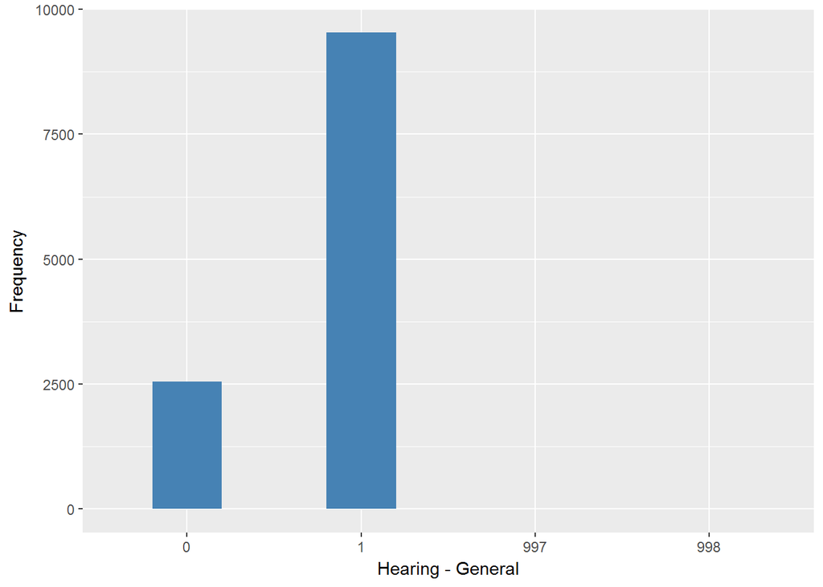

#### 2.1.1.4 Validation

|  | 4,5->0 | 1,2,3->1 | -9->997 | -8->998 |
| --- | --- | --- | --- | --- |
| BeforeH | 2551 | 9537 | 4 | 7 |
| AfterH | 2551 | 9537 | 4 | 7 |

### 2.1.2 Wave 2

#### 2.1.2.1 Study-specific variable description

| **Name** | `hehear` |
| --- | --- |
| **Label** | `Self-reported hearing (while using hearing aid if appropriate)?` |
| **Table name** | `wave_2_core_data_v4` |
| **Categories** | `1 = ...excellent; 2 = very good; 3 = good; 4 = fair; 5 = or, poor?` |
| **Missings** | `-9 = Refusal; -8 = Don't Know` |
| **Description** |  |

Hehear

| Sample size | Missing values |
| --- | --- |
| 9432 | 4 |

Category

|  | 1 | 2 | 3 | 4 | 5 |
| --- | --- | --- | --- | --- | --- |
| Frequency | 1914.00 | 2575.0 | 2947.00 | 1517.00 | 475.00 |
| Percentage | 20.29 | 27.3 | 31.24 | 16.08 | 5.04 |

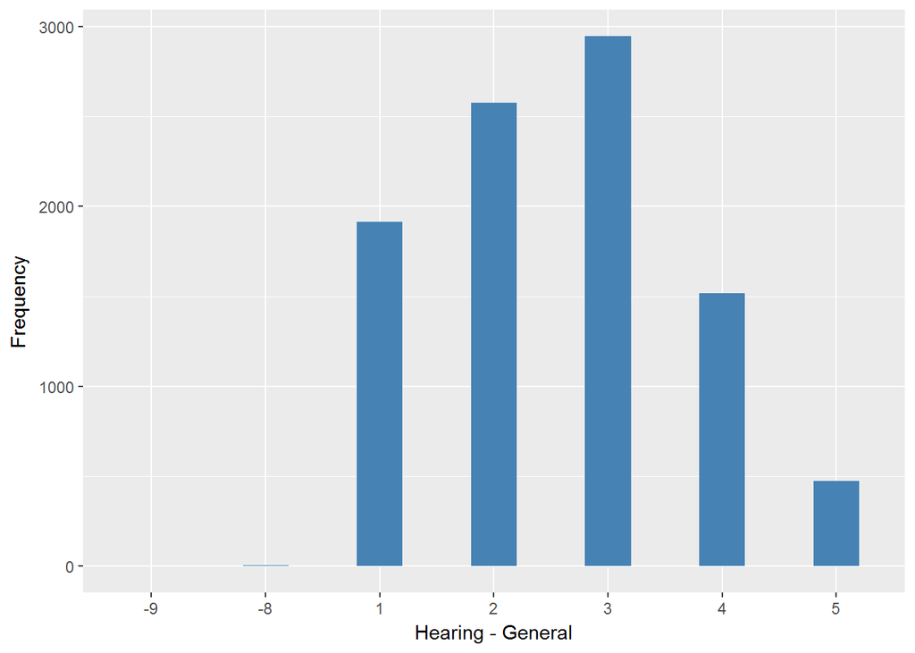

#### 2.1.2.2 Harmonisation algorithm

To compute the harmonize variable from the study-specific variable it has to be recoded as follows:

- `4,5 into 0`
- `1,2,3 into 1`
- `-9 Refusal into 997`
- `-8 Don't know into 998`

**R script:**

```r
ELSA_ds_w2 <- tibble(id = ELSA_w2_hearing_gen$id)
ELSA_ds_w2$hearing_gen <- car::recode(ELSA_w2_hearing_gen$Hehear, "4 = '0';5 = '0';1 = '1';2 = '1';3 = '1';-9 = '997';-8 = '998';-1 = '996' ")
ELSA_ds_w2$hearing_gen <- labelled(ELSA_ds_w2$hearing_gen, labels = c(Yes = 0,
    No = 1, Missing = 999, Do_not_know = 998, Refuse = 997, Not_applicable = 996,
    Does_not_answer = 995, Not_attempt_not_done = 994, Disable_to_measure = 993,
    Impute = 992, CAPI_interviewer_error = 991))
```

#### 2.1.2.3 Statistical description of the new harmonised variable

hearing_gen

| Sample size | Missing values |
| --- | --- |
| 9432 | 4 |

Category

|  | 0 | 1 |
| --- | --- | --- |
| Frequency | 1992.00 | 7436.00 |
| Percentage | 21.12 | 78.84 |

Type of missing

|  | 991 | 992 | 993 | 994 | 995 | 996 | 997 | 998 | 999 | NA |
| --- | --- | --- | --- | --- | --- | --- | --- | --- | --- | --- |
| Frequency | 0 | 0 | 0 | 0 | 0 | 0 | 1.00 | 3.00 | 0 | 0 |
| Percentage | 0 | 0 | 0 | 0 | 0 | 0 | 0.01 | 0.03 | 0 | 0 |

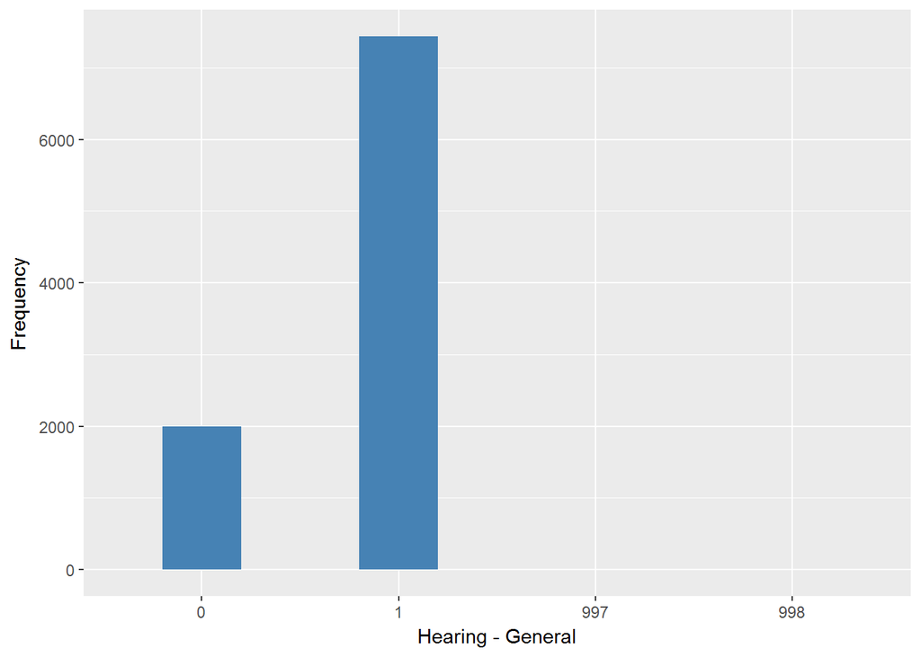

#### 2.1.2.4 Validation

|  | 4,5->0 | 1,2,3->1 | -9->997 | -8->998 |
| --- | --- | --- | --- | --- |
| BeforeH | 1992 | 7436 | 1 | 3 |
| AfterH | 1992 | 7436 | 1 | 3 |

### 2.1.3 Wave 3

#### 2.1.3.1 Study-specific variable description

| **Name** | `hehear` |
| --- | --- |
| **Label** | `Self-reported hearing (while using hearing aid if appropriate)?` |
| **Table name** | `wave_3_elsa_data_v4` |
| **Categories** | `1 = ...excellent; 2 = very good; 3 = good; 4 = fair; 5 = or, poor?` |
| **Missings** | `-9 = Refusal; -8 = Don't Know` |
| **Description** |  |

hehear

| Sample size | Missing values |
| --- | --- |
| 9771 | 5 |

Category

|  | 1 | 2 | 3 | 4 | 5 |
| --- | --- | --- | --- | --- | --- |
| Frequency | 1965.00 | 2521.0 | 3203.00 | 1610.00 | 467.00 |
| Percentage | 20.11 | 25.8 | 32.78 | 16.48 | 4.78 |

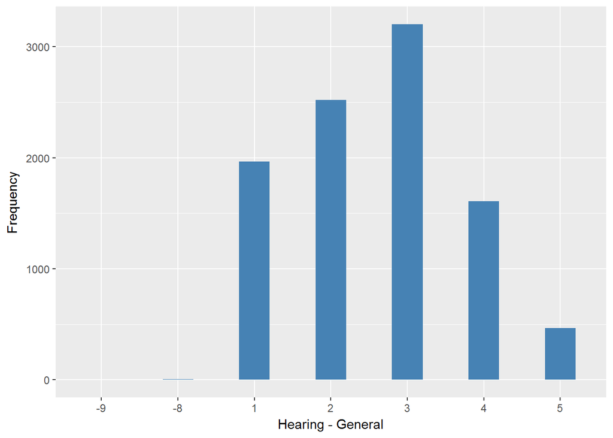

#### 2.1.3.2 Harmonisation algorithm

To compute the harmonize variable from the study-specific variable it has to be recoded as follows:

- `4,5 into 0`
- `1,2,3 into 1`
- `-9 Refusal into 997`
- `-8 Don't know into 998`

**R script:**

```r
ELSA_ds_w3 <- tibble(id = ELSA_w3_hearing_gen$id)
ELSA_ds_w3$hearing_gen <- car::recode(ELSA_w3_hearing_gen$hehear, "4 = '0';5 = '0';1 = '1';2 = '1';3 = '1';-9 = '997';-8 = '998';-1 = '996' ")
ELSA_ds_w3$hearing_gen <- labelled(ELSA_ds_w3$hearing_gen, labels = c(Yes = 0,
    No = 1, Missing = 999, Do_not_know = 998, Refuse = 997, Not_applicable = 996,
    Does_not_answer = 995, Not_attempt_not_done = 994, Disable_to_measure = 993,
    Impute = 992, CAPI_interviewer_error = 991))
```

#### 2.1.3.3 Statistical description of the new harmonised variable

hearing_gen

| Sample size | Missing values |
| --- | --- |
| 9771 | 5 |

Category

|  | 0 | 1 |
| --- | --- | --- |
| Frequency | 2077.00 | 7689.00 |
| Percentage | 21.26 | 78.69 |

Type of missing

|  | 991 | 992 | 993 | 994 | 995 | 996 | 997 | 998 | 999 | NA |
| --- | --- | --- | --- | --- | --- | --- | --- | --- | --- | --- |
| Frequency | 0 | 0 | 0 | 0 | 0 | 0 | 2.00 | 3.00 | 0 | 0 |
| Percentage | 0 | 0 | 0 | 0 | 0 | 0 | 0.02 | 0.03 | 0 | 0 |

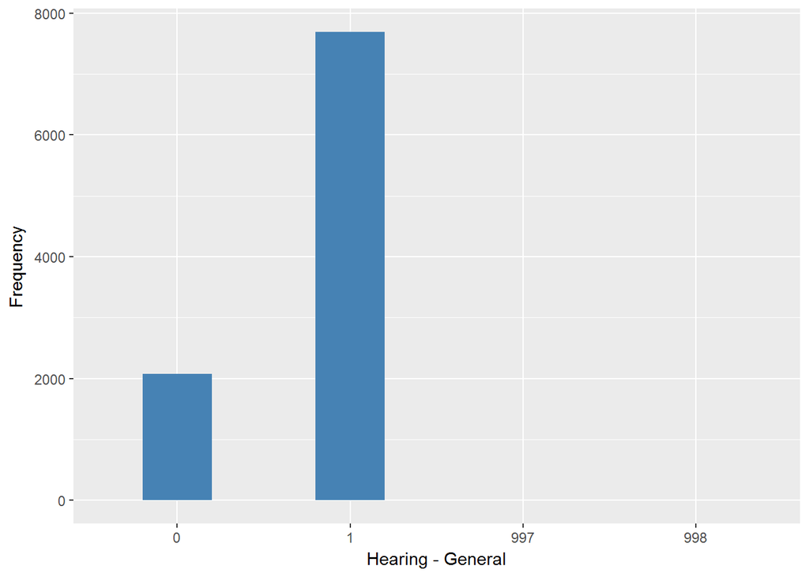

#### 2.1.3.4 Validation

|  | 4,5->0 | 1,2,3->1 | -9->997 | -8->998 |
| --- | --- | --- | --- | --- |
| BeforeH | 2077 | 7689 | 2 | 3 |
| AfterH | 2077 | 7689 | 2 | 3 |

### 2.1.4 Wave 4

#### 2.1.4.1 Study-specific variable description

| **Name** | `hehear` |
| --- | --- |
| **Label** | `Self-reported hearing (while using hearing aid if appropriate)?` |
| **Table name** | `wave_4_elsa_data_v3` |
| **Categories** | `1 = ...excellent; 2 = very good; 3 = good; 4 = fair; 5 = or, poor?` |
| **Missings** | `-9 = Refusal; -8 = Don't Know` |
| **Description** |  |

hehear

| Sample size | Missing values |
| --- | --- |
| 11050 | 9 |

Category

|  | 1 | 2 | 3 | 4 | 5 |
| --- | --- | --- | --- | --- | --- |
| Frequency | 2163.00 | 3047.00 | 3598.00 | 1728.00 | 505.00 |
| Percentage | 19.57 | 27.57 | 32.56 | 15.64 | 4.57 |

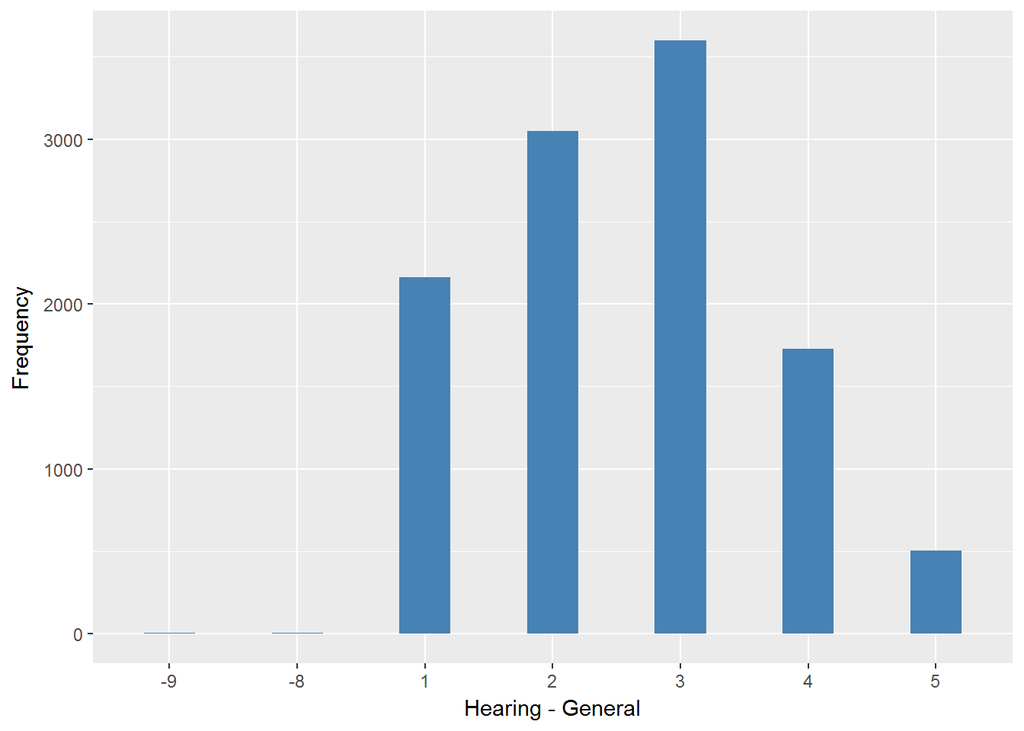

#### 2.1.4.2 Harmonisation algorithm

To compute the harmonize variable from the study-specific variable it has to be recoded as follows:

- `4,5 into 0`
- `1,2,3 into 1`
- `-9 Refusal into 997`
- `-8 Don't know into 998`

**R script:**

```r
ELSA_ds_w4 <- tibble(id = ELSA_w4_hearing_gen$id)
ELSA_ds_w4$hearing_gen <- car::recode(ELSA_w4_hearing_gen$hehear, "4 = '0';5 = '0';1 = '1';2 = '1';3 = '1';-9 = '997';-8 = '998';-1 = '996' ")
ELSA_ds_w4$hearing_gen <- labelled(ELSA_ds_w4$hearing_gen, labels = c(Yes = 0,
    No = 1, Missing = 999, Do_not_know = 998, Refuse = 997, Not_applicable = 996,
    Does_not_answer = 995, Not_attempt_not_done = 994, Disable_to_measure = 993,
    Impute = 992, CAPI_interviewer_error = 991))
```

#### 2.1.4.3 Statistical description of the new harmonised variable

hearing_gen

| Sample size | Missing values |
| --- | --- |
| 11050 | 9 |

Category

|  | 0 | 1 |
| --- | --- | --- |
| Frequency | 2233.00 | 8808.00 |
| Percentage | 20.21 | 79.71 |

Type of missing

|  | 991 | 992 | 993 | 994 | 995 | 996 | 997 | 998 | 999 | NA |
| --- | --- | --- | --- | --- | --- | --- | --- | --- | --- | --- |
| Frequency | 0 | 0 | 0 | 0 | 0 | 0 | 5.00 | 4.00 | 0 | 0 |
| Percentage | 0 | 0 | 0 | 0 | 0 | 0 | 0.05 | 0.04 | 0 | 0 |

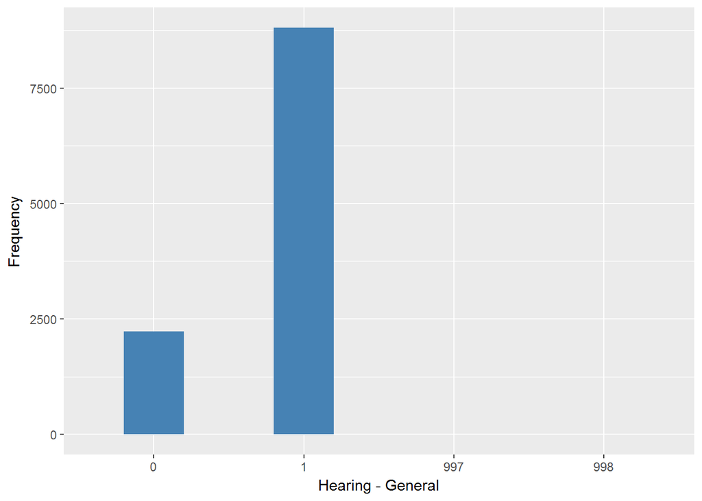

#### 2.1.4.4 Validation

|  | 4,5->0 | 1,2,3->1 | -9->997 | -8->998 |
| --- | --- | --- | --- | --- |
| BeforeH | 2233 | 8808 | 5 | 4 |
| AfterH | 2233 | 8808 | 5 | 4 |

### 2.1.5 Wave 5

#### 2.1.5.1 Study-specific variable description

| **Name** | `hehear` |
| --- | --- |
| **Label** | `Self-reported hearing (while using hearing aid if appropriate)?` |
| **Table name** | `wave_5_elsa_data_v4` |
| **Categories** | `1 = ...excellent; 2 = very good; 3 = good; 4 = fair; 5 = or, poor?` |
| **Missings** | `-9 = Refusal; -8 = Don't Know` |
| **Description** |  |

hehear

| Sample size | Missing values |
| --- | --- |
| 10274 | 11 |

Category

|  | 1 | 2 | 3 | 4 | 5 |
| --- | --- | --- | --- | --- | --- |
| Frequency | 1840.00 | 2988.00 | 3293.00 | 1636.00 | 506.00 |
| Percentage | 17.91 | 29.08 | 32.05 | 15.92 | 4.93 |

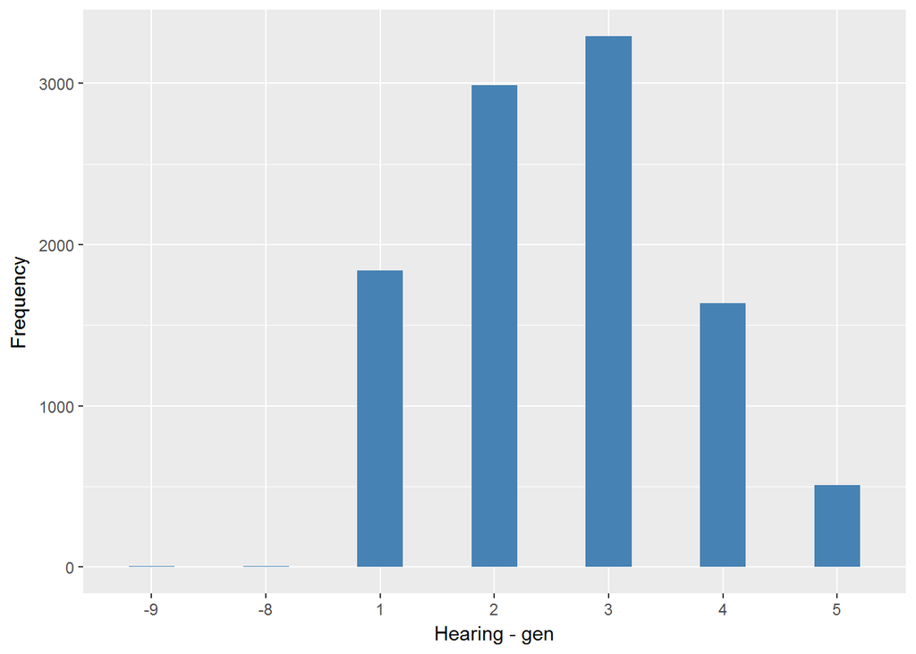

#### 2.1.5.2 Harmonisation algorithm

To compute the harmonize variable from the study-specific variable it has to be recoded as follows:

- `4,5 into 0`
- `1,2,3 into 1`
- `-9 Refusal into 997`
- `-8 Don't know into 998`

**R script:**

```r
ELSA_ds_w5 <- tibble(id = ELSA_w5_hearing_gen$id)
ELSA_ds_w5$hearing_gen <- car::recode(ELSA_w5_hearing_gen$hehear, "4 = '0';5 = '0';1 = '1';2 = '1';3 = '1';-9 = '997';-8 = '998';-1 = '996' ")
ELSA_ds_w5$hearing_gen <- labelled(ELSA_ds_w5$hearing_gen, labels = c(Yes = 0,
    No = 1, Missing = 999, Do_not_know = 998, Refuse = 997, Not_applicable = 996,
    Does_not_answer = 995, Not_attempt_not_done = 994, Disable_to_measure = 993,
    Impute = 992, CAPI_interviewer_error = 991))
```

#### 2.1.5.3 Statistical description of the new harmonised variable

hearing_gen

| Sample size | Missing values |
| --- | --- |
| 10274 | 11 |

Category

|  | 0 | 1 |
| --- | --- | --- |
| Frequency | 2142.00 | 8121.00 |
| Percentage | 20.85 | 79.04 |

Type of missing

|  | 991 | 992 | 993 | 994 | 995 | 996 | 997 | 998 | 999 | NA |
| --- | --- | --- | --- | --- | --- | --- | --- | --- | --- | --- |
| Frequency | 0 | 0 | 0 | 0 | 0 | 0 | 5.00 | 6.00 | 0 | 0 |
| Percentage | 0 | 0 | 0 | 0 | 0 | 0 | 0.05 | 0.06 | 0 | 0 |

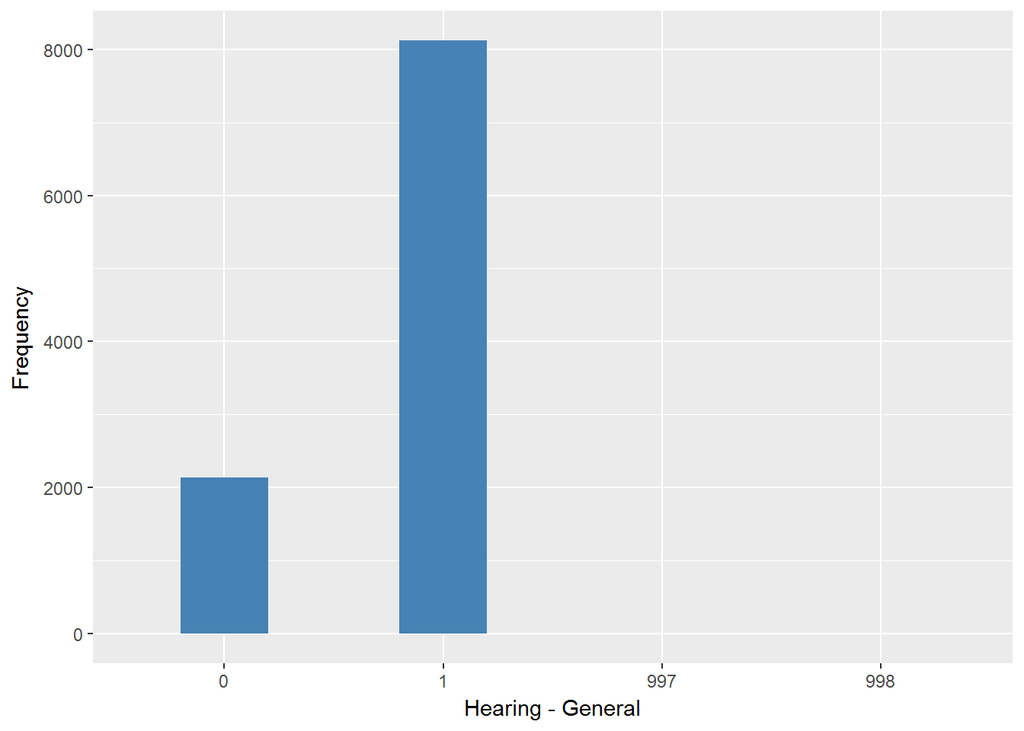

#### 2.1.5.4 Validation

|  | 4,5->0 | 1,2,3->1 | -9->997 | -8->998 |
| --- | --- | --- | --- | --- |
| BeforeH | 2142 | 8121 | 5 | 6 |
| AfterH | 2142 | 8121 | 5 | 6 |

### 2.1.6 Wave 6

#### 2.1.6.1 Study-specific variable description

| **Name** | `hehear` |
| --- | --- |
| **Label** | `Self-reported hearing (while using hearing aid if appropriate)?` |
| **Table name** | `wave_6_elsa_data_v2` |
| **Categories** | `1 = ...excellent; 2 = very good; 3 = good; 4 = fair; 5 = or, poor?` |
| **Missings** | `-9 = Refusal; -8 = Don't Know` |
| **Description** |  |

HeHear

| Sample size | Missing values |
| --- | --- |
| 10601 | 7 |

Category

|  | 1 | 2 | 3 | 4 | 5 |
| --- | --- | --- | --- | --- | --- |
| Frequency | 1947.00 | 2914.00 | 3440.00 | 1770.0 | 523.00 |
| Percentage | 18.37 | 27.49 | 32.45 | 16.7 | 4.93 |

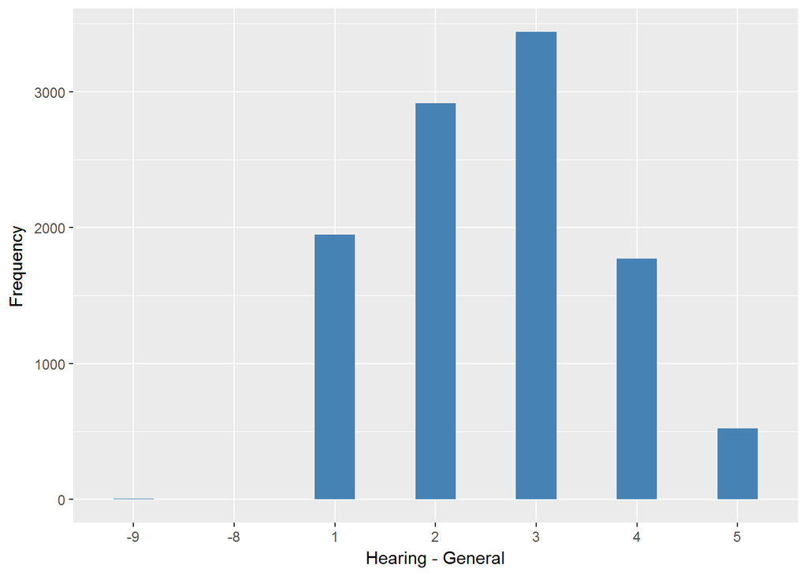

#### 2.1.6.2 Harmonisation algorithm

To compute the harmonize variable from the study-specific variable it has to be recoded as follows:

- `4,5 into 0`
- `1,2,3 into 1`
- `-9 Refusal into 997`
- `-8 Don't know into 998`

**R script:**

```r
ELSA_ds_w6 <- tibble(id = ELSA_w6_hearing_gen$id)
ELSA_ds_w6$hearing_gen <- car::recode(ELSA_w6_hearing_gen$HeHear, "4 = '0';5 = '0';1 = '1';2 = '1';3 = '1';-9 = '997';-8 = '998';-1 = '996' ")
ELSA_ds_w6$hearing_gen <- labelled(ELSA_ds_w6$hearing_gen, labels = c(Yes = 0,
    No = 1, Missing = 999, Do_not_know = 998, Refuse = 997, Not_applicable = 996,
    Does_not_answer = 995, Not_attempt_not_done = 994, Disable_to_measure = 993,
    Impute = 992, CAPI_interviewer_error = 991))
```

#### 2.1.6.3 Statistical description of the new harmonised variable

hearing_gen

| Sample size | Missing values |
| --- | --- |
| 10601 | 7 |

Category

|  | 0 | 1 |
| --- | --- | --- |
| Frequency | 2293.00 | 8301.0 |
| Percentage | 21.63 | 78.3 |

Type of missing

|  | 991 | 992 | 993 | 994 | 995 | 996 | 997 | 998 | 999 | NA |
| --- | --- | --- | --- | --- | --- | --- | --- | --- | --- | --- |
| Frequency | 0 | 0 | 0 | 0 | 0 | 0 | 5.00 | 2.00 | 0 | 0 |
| Percentage | 0 | 0 | 0 | 0 | 0 | 0 | 0.05 | 0.02 | 0 | 0 |

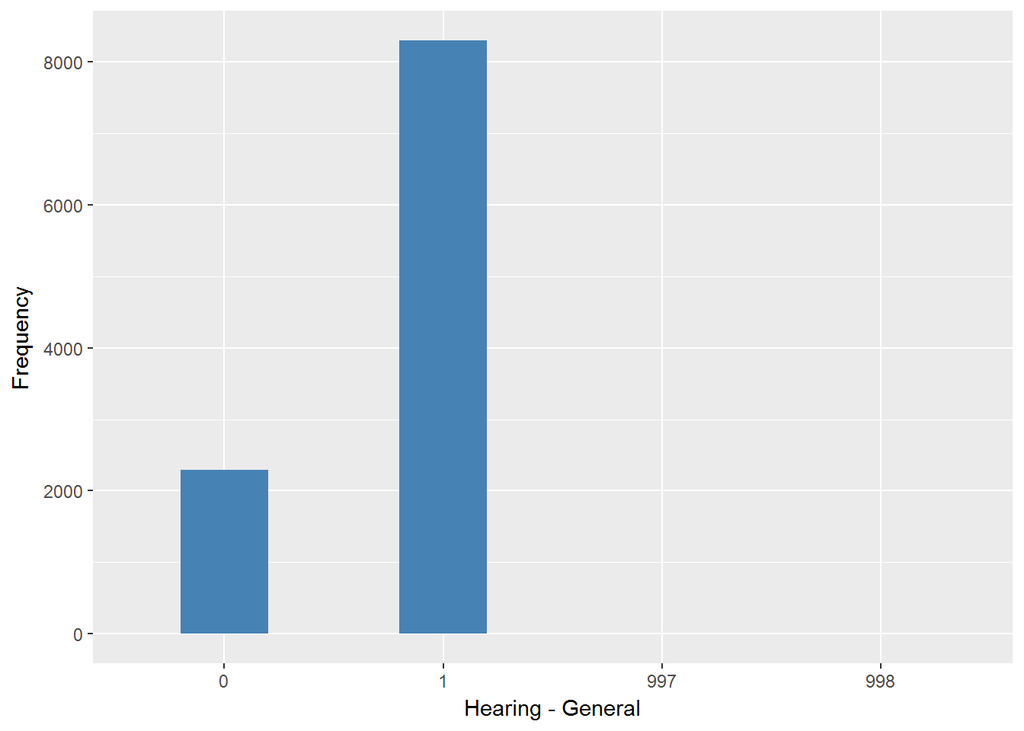

#### 2.1.6.4 Validation

|  | 4,5->0 | 1,2,3->1 | -9->997 | -8->998 |
| --- | --- | --- | --- | --- |
| BeforeH | 2293 | 8301 | 5 | 2 |
| AfterH | 2293 | 8301 | 5 | 2 |

### 2.1.7 Wave 7

#### 2.1.7.1 Study-specific variable description

| **Name** | `hehear` |
| --- | --- |
| **Label** | `Self-reported hearing (while using hearing aid if appropriate)?` |
| **Table name** | `wave_7_elsa_data` |
| **Categories** | `1 = ...excellent; 2 = very good; 3 = good; 4 = fair; 5 = or, poor?` |
| **Missings** | `-8 = Don't Know` |
| **Description** |  |

HeHear

| Sample size | Missing values |
| --- | --- |
| 9666 | 3 |

Category

|  | 1 | 2 | 3 | 4 | 5 |
| --- | --- | --- | --- | --- | --- |
| Frequency | 1678.00 | 2674.00 | 3225.00 | 1573.00 | 513.00 |
| Percentage | 17.36 | 27.66 | 33.36 | 16.27 | 5.31 |

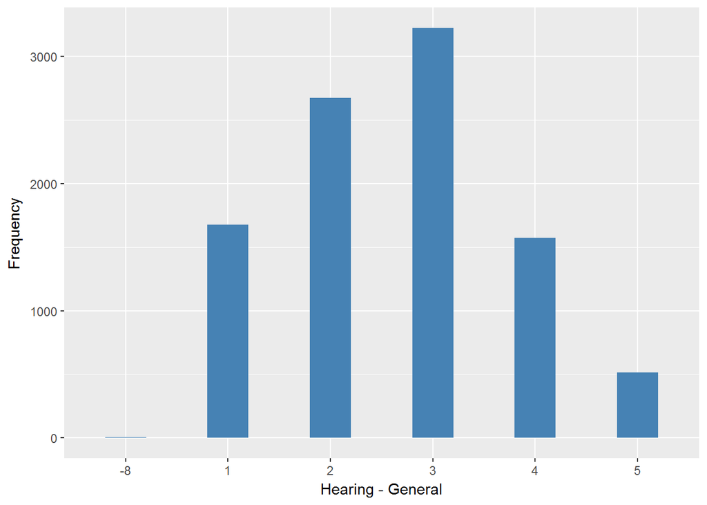

#### 2.1.7.2 Harmonisation algorithm

To compute the harmonize variable from the study-specific variable it has to be recoded as follows:

- `4,5 into 0`
- `1,2,3 into 1`
- `-8 Don't know into 998`

**R script:**

```r
ELSA_ds_w7 <- tibble(id = ELSA_w7_hearing_gen$id)
ELSA_ds_w7$hearing_gen <- car::recode(ELSA_w7_hearing_gen$HeHear, "4 = '0';5 = '0';1 = '1';2 = '1';3 = '1';-9 = '997';-8 = '998';-1 = '996' ")
ELSA_ds_w7$hearing_gen <- labelled(ELSA_ds_w7$hearing_gen, labels = c(Yes = 0,
    No = 1, Missing = 999, Do_not_know = 998, Refuse = 997, Not_applicable = 996,
    Does_not_answer = 995, Not_attempt_not_done = 994, Disable_to_measure = 993,
    Impute = 992, CAPI_interviewer_error = 991))
```

#### 2.1.7.3 Statistical description of the new harmonised variable

hearing_gen

| Sample size | Missing values |
| --- | --- |
| 9666 | 3 |

Category

|  | 0 | 1 |
| --- | --- | --- |
| Frequency | 2086.00 | 7577.00 |
| Percentage | 21.58 | 78.39 |

Type of missing

|  | 991 | 992 | 993 | 994 | 995 | 996 | 997 | 998 | 999 | NA |
| --- | --- | --- | --- | --- | --- | --- | --- | --- | --- | --- |
| Frequency | 0 | 0 | 0 | 0 | 0 | 0 | 0 | 3.00 | 0 | 0 |
| Percentage | 0 | 0 | 0 | 0 | 0 | 0 | 0 | 0.03 | 0 | 0 |

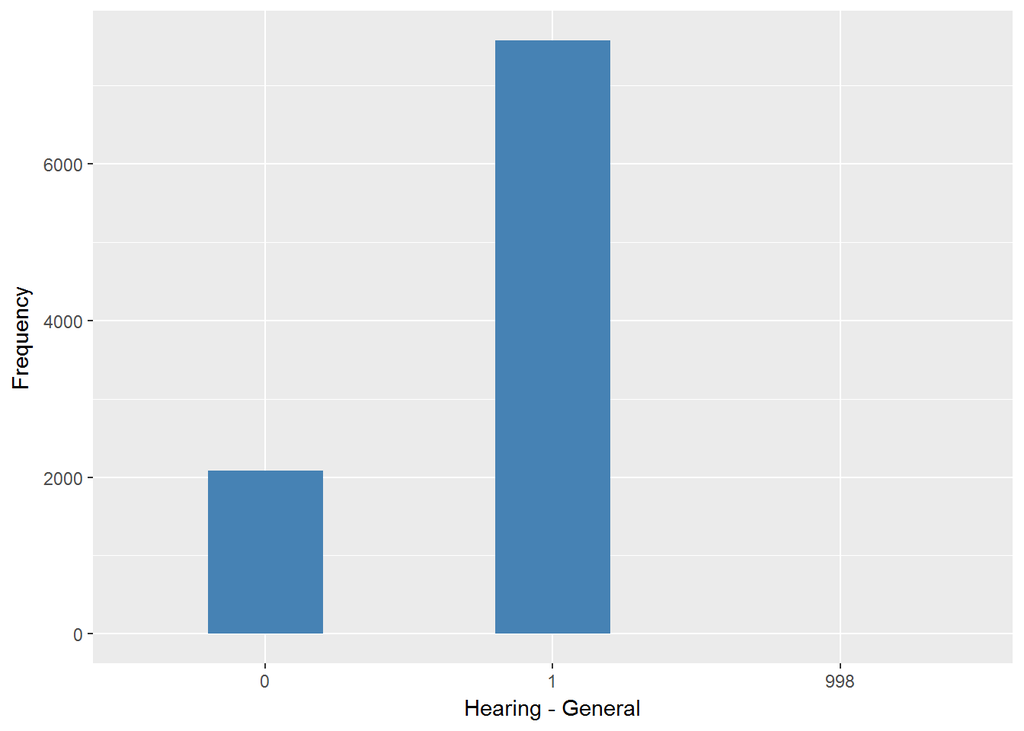

#### 2.1.7.4 Validation

|  | 4,5->0 | 1,2,3->1 | -8->998 |
| --- | --- | --- | --- |
| BeforeH | 2086 | 7577 | 3 |
| AfterH | 2086 | 7577 | 3 |

## 2.2 Summary of descriptive statistics of the harmonised variable accross populations and waves

Two tables are generated:

1. Percentages of categories in each harmonised variable.
2. Frequencies and percentages of individuals with different trajectories. To avoid too large table, Only trajectories with percentages larger than 0.3 are shown.

**R script:**

```r
ELSA_ds_w1$hearing_gen <- labelled(ELSA_ds_w1$hearing_gen, labels = c(Presence = 0,
    Absence = 1, Missing = 999, Do_not_know = 998, Refuse = 997, Not_applicable = 996,
    Does_not_answer = 995, Not_attempt_not_done = 994, Disable_to_measure = 993,
    Impute = 992, CAPI_interviewer_error = 991))
ELSA_ds_w2$hearing_gen <- labelled(ELSA_ds_w2$hearing_gen, labels = c(Presence = 0,
    Absence = 1, Missing = 999, Do_not_know = 998, Refuse = 997, Not_applicable = 996,
    Does_not_answer = 995, Not_attempt_not_done = 994, Disable_to_measure = 993,
    Impute = 992, CAPI_interviewer_error = 991))
ELSA_ds_w3$hearing_gen <- labelled(ELSA_ds_w3$hearing_gen, labels = c(Presence = 0,
    Absence = 1, Missing = 999, Do_not_know = 998, Refuse = 997, Not_applicable = 996,
    Does_not_answer = 995, Not_attempt_not_done = 994, Disable_to_measure = 993,
    Impute = 992, CAPI_interviewer_error = 991))
ELSA_ds_w4$hearing_gen <- labelled(ELSA_ds_w4$hearing_gen, labels = c(Presence = 0,
    Absence = 1, Missing = 999, Do_not_know = 998, Refuse = 997, Not_applicable = 996,
    Does_not_answer = 995, Not_attempt_not_done = 994, Disable_to_measure = 993,
    Impute = 992, CAPI_interviewer_error = 991))
ELSA_ds_w5$hearing_gen <- labelled(ELSA_ds_w5$hearing_gen, labels = c(Presence = 0,
    Absence = 1, Missing = 999, Do_not_know = 998, Refuse = 997, Not_applicable = 996,
    Does_not_answer = 995, Not_attempt_not_done = 994, Disable_to_measure = 993,
    Impute = 992, CAPI_interviewer_error = 991))
ELSA_ds_w6$hearing_gen <- labelled(ELSA_ds_w6$hearing_gen, labels = c(Presence = 0,
    Absence = 1, Missing = 999, Do_not_know = 998, Refuse = 997, Not_applicable = 996,
    Does_not_answer = 995, Not_attempt_not_done = 994, Disable_to_measure = 993,
    Impute = 992, CAPI_interviewer_error = 991))
ELSA_ds_w7$hearing_gen <- labelled(ELSA_ds_w7$hearing_gen, labels = c(Presence = 0,
    Absence = 1, Missing = 999, Do_not_know = 998, Refuse = 997, Not_applicable = 996,
    Does_not_answer = 995, Not_attempt_not_done = 994, Disable_to_measure = 993,
    Impute = 992, CAPI_interviewer_error = 991))

tt <- frq(ELSA_ds_w1$hearing_gen)[[1]][, c(1:2, 4)]
tt[4] <- frq(ELSA_ds_w2$hearing_gen)[[1]][, c(4)]
tt[5] <- frq(ELSA_ds_w3$hearing_gen)[[1]][, c(4)]
tt[6] <- frq(ELSA_ds_w4$hearing_gen)[[1]][, c(4)]
tt[7] <- frq(ELSA_ds_w5$hearing_gen)[[1]][, c(4)]
tt[8] <- frq(ELSA_ds_w6$hearing_gen)[[1]][, c(4)]
tt[9] <- frq(ELSA_ds_w7$hearing_gen)[[1]][, c(4)]
tt[13, ] <- c("n", "sample size", length(ELSA_ds_w1$hearing_gen), length(ELSA_ds_w2$hearing_gen),
    length(ELSA_ds_w3$hearing_gen), length(ELSA_ds_w4$hearing_gen), length(ELSA_ds_w5$hearing_gen),
    length(ELSA_ds_w6$hearing_gen), length(ELSA_ds_w7$hearing_gen))
names(tt) <- c("val", "label", "w1", "w2", "w3", "w4", "w5", "w6", "w7")
kable(tt)
```

| val | label | w1 | w2 | w3 | w4 | w5 | w6 | w7 |
| --- | --- | --- | --- | --- | --- | --- | --- | --- |
| 0 | Presence | 21.08 | 21.12 | 21.26 | 20.21 | 20.85 | 21.63 | 21.58 |
| 1 | Absence | 78.82 | 78.84 | 78.69 | 79.71 | 79.04 | 78.3 | 78.39 |
| 991 | CAPI_interviewer_error | 0 | 0 | 0 | 0 | 0 | 0 | 0 |
| 992 | Impute | 0 | 0 | 0 | 0 | 0 | 0 | 0 |
| 993 | Disable_to_measure | 0 | 0 | 0 | 0 | 0 | 0 | 0 |
| 994 | Not_attempt_not_done | 0 | 0 | 0 | 0 | 0 | 0 | 0 |
| 995 | Does_not_answer | 0 | 0 | 0 | 0 | 0 | 0 | 0 |
| 996 | Not_applicable | 0 | 0 | 0 | 0 | 0 | 0 | 0 |
| 997 | Refuse | 0.03 | 0.01 | 0.02 | 0.05 | 0.05 | 0.05 | 0 |
| 998 | Do_not_know | 0.06 | 0.03 | 0.03 | 0.04 | 0.06 | 0.02 | 0.03 |
| 999 | Missing | 0 | 0 | 0 | 0 | 0 | 0 | 0 |
| NA | NA | 0 | 0 | 0 | 0 | 0 | 0 | 0 |
| n | sample size | 12099 | 9432 | 9771 | 11050 | 10274 | 10601 | 9666 |

```r
dbb <- merge(ELSA_m_ds_w1, ELSA_m_ds_w2, by = "id", suffixes = c(".w1", ".w2"),
    all = T)
dbb <- merge(dbb, ELSA_m_ds_w3, by = "id", all = T)
dbb <- merge(dbb, ELSA_m_ds_w4, by = "id", suffixes = c(".w3", ".w4"), all = T)
dbb <- merge(dbb, ELSA_m_ds_w5, by = "id", all = T)
dbb <- merge(dbb, ELSA_m_ds_w6, by = "id", suffixes = c(".w5", ".w6"), all = T)
dbb <- merge(dbb, ELSA_m_ds_w7, by = "id", all = T)
names(dbb) <- c("id", "w1", "w2", "w3", "w4", "w5", "w6", "w7")
v.dbb <- paste(dbb[, 2], dbb[, 3], dbb[, 4], dbb[, 5], dbb[, 6], dbb[, 7], dbb[,
    8], sep = "")
f.dbb <- frq(v.dbb)[[1]][, c(1, 2, 4)]
kable(f.dbb[f.dbb[, 3] >= 0.3, ])
```

|  | val | frq | raw.prc |
| --- | --- | --- | --- |
| 1 | 0000000 | 156 | 0.84 |
| 20 | 0000NANANA | 72 | 0.39 |
| 50 | 000NANANANA | 129 | 0.70 |
| 122 | 00NANANANANA | 199 | 1.08 |
| 232 | 01NANANANANA | 84 | 0.45 |
| 296 | 0NANANANANANA | 544 | 2.94 |
| 396 | 10NANANANANA | 129 | 0.70 |
| 446 | 110NANANANA | 58 | 0.31 |
| 472 | 1111011 | 57 | 0.31 |
| 477 | 1111100 | 72 | 0.39 |
| 478 | 1111101 | 99 | 0.54 |
| 480 | 1111110 | 168 | 0.91 |
| 481 | 1111111 | 2465 | 13.33 |
| 482 | 111111NA | 349 | 1.89 |
| 485 | 11111NANA | 238 | 1.29 |
| 492 | 1111NANANA | 324 | 1.75 |
| 503 | 111NA111 | 69 | 0.37 |
| 513 | 111NANANANA | 553 | 2.99 |
| 537 | 11NA1111 | 56 | 0.30 |
| 565 | 11NANANANANA | 879 | 4.75 |
| 601 | 1NA11111 | 65 | 0.35 |
| 620 | 1NA1NANANANA | 74 | 0.40 |
| 667 | 1NANANANANANA | 1536 | 8.31 |
| 788 | NANA11111 | 619 | 3.35 |
| 789 | NANA1111NA | 88 | 0.48 |
| 792 | NANA111NANA | 70 | 0.38 |
| 798 | NANA11NANANA | 98 | 0.53 |
| 815 | NANA1NANANANA | 269 | 1.45 |
| 816 | NANANA0000 | 107 | 0.58 |
| 841 | NANANA0NANANA | 77 | 0.42 |
| 854 | NANANA1110 | 78 | 0.42 |
| 855 | NANANA1111 | 1141 | 6.17 |
| 856 | NANANA111NA | 178 | 0.96 |
| 859 | NANANA11NANA | 131 | 0.71 |
| 868 | NANANA1NANANA | 285 | 1.54 |
| 881 | NANANANA111 | 59 | 0.32 |
| 885 | NANANANANA00 | 82 | 0.44 |
| 888 | NANANANANA10 | 65 | 0.35 |
| 889 | NANANANANA11 | 754 | 4.08 |
| 890 | NANANANANA1NA | 240 | 1.30 |
| 891 | NANANANANANA0 | 73 | 0.39 |
| 892 | NANANANANANA1 | 437 | 2.36 |

# 3 Quality estimation

No comments.